# STAT 331 Portfolio

Author

Daltzwer Oliveros

**My Grade:** I believe my grade equivalent to course work evidenced below to be a B. I feel I have already improved so much on my coding skills and have felt quite proud of what I have been able to accomplish thus far.

**Learning Objective Evidence:** In the code chunks below, provide code from a Lab or Challenge assignment where you believe you have demonstrated proficiency with the specified learning target. Be sure to specify **where** the code came from (e.g., Lab 4 Question 2).

## Working with Data

**WD-1: I can import data from a *variety* of formats (e.g., csv, xlsx, txt, etc.).**

- `csv` Lab 4

```r
avocado <- read_csv(here("Week 4", "Labs", "avocado.csv"))
```

- `xlsx` Practice Activity 4

```r
library(readxl)
library(tidyverse)

military <- read_xlsx(here::here("data",
                                 "gov_spending_per_capita.xlsx"),
                      sheet = "Share of Govt. spending"  ,
                      skip = 6,
                      n_max = 186 )
```

- `txt` Practice Activity 5.2

```r
message <- read_csv(here::here(
                                 "data",
                                 "scrambled_message.txt")
                      )
```

**WD-2: I can select necessary columns from a dataset.** Lab 3 Question 9

```r
 # code chunk for Q9
demodata <- hiphop_clean |>
  select(subj, age, sex, ethnic1) |>
  distinct(subj, .keep_all = TRUE)
demodata |>
  count(sex)
```

**WD-3: I can filter rows from a dataframe for a *variety* of data types (e.g., numeric, integer, character, factor, date).**

- numeric Lab 3 question 11

```r
 subj_fam <- hiphop_clean |>
  filter( age < 20) |>
  group_by(word) |>
  summarise(mean_fam = mean(familiarity))

subj_fam|>
  slice_min(mean_fam)

subj_fam|>
  slice_max(mean_fam)
```

- character – specifically a string CHallenge 3 Question White vs NonWHite

```r
white_genre <- hiphop_clean |>
  filter( ethnic1 == "white") |>
  select(intl, vocal, classical, folk, rock, country, pop, alternative, hiphop, unclassifiable) |>
  summarise_all(mean)
white_genre
```

- factor Lab 3 Question 12

```r
nw_women_fam <- hiphop_clean |>
  filter( ethnic1 == "non-white", sex == "Female") |>
  group_by(word) |>
  summarise(mean_fam = mean(familiarity))

nw_women_fam|>
  slice_min(mean_fam)

nw_women_fam|>
  slice_max(mean_fam)
```

- date Practice Activity 5.1 Question 3

```r
suspects_ <- suspects |>
  filter(Time.Spotted %within% within_thanks)
```

**WD-4: I can modify existing variables and create new variables in a dataframe for a *variety* of data types (e.g., numeric, integer, character, factor, date).**

- numeric lab 4 question 6

```r
California <- avocado_metro |>
  filter(region %in% c("LosAngeles", "SanDiego", "Sacramento", "SanFrancisco")) |>
  group_by(region, type) |>
  summarise(AvocadoPrice = mean(AveragePrice),
            .groups = "keep") |>
  pivot_wider(names_from = type,
              values_from = AvocadoPrice) |>
  mutate(PriceDifference = organic - conventional) |>
  arrange(desc(PriceDifference))
California
```

- character – specifically a string Lab 8 part 1

```r
# Produces the string for one day of the song.
# Arguments -- dataset: A data frame containing information about gifts
# Arguments -- line: The number of the line for the day you want to sing about
# Arguments -- phrase_col: The variable name for the column in the dataset that contains the song phrases
# Return -- A string singing the line of the song with all gifts for the given day.

sing_day <- function(dataset, line, phrase_col){

  # Step 1: Setup the intro line
  # Hint: You need to convert a number (e.g., 1) to a word (e.g., first)
  num_word <- ordinal(line)

  intro <- glue::glue("On the {num_word} day of Christmas, my true love gave to me:")

  # Step 2: Sing the gift phrases

    phrases <- dataset |>
      pull( {{phrase_col}} )
     if(line == 1){
     phrases[1] <- str_replace(phrases[1], "and ", "")
    }
    phrases <- c(intro,phrases[line:1])
    phrases <- glue_collapse(phrases, sep = "\n")



  ## put it together
    return(phrases)


}
```

- factor - Lab 5 Question 2.3

```r
 AverageWeight2 <- surveys |>
  mutate(genus = fct_rev(fct_reorder(genus , weight, mean))) |>
  group_by(genus, year) |>
  summarise(AverageWeight = mean(weight), .groups = "keep")

ggplot(data = AverageWeight2,
       mapping = aes(x = year, y = AverageWeight, color = genus)) +
  geom_line() +
  labs(x = "Year of Observation",
       y = "Average Weight (Grams)",
       color = "Genus of Rodent")
```

- date Practice Activity 5.1 Question 1

```r
suspects <- suspects |>
  mutate(Time.Spotted = ymd_hms(Time.Spotted),
         Time.Spotted = force_tz(Time.Spotted, tzone = "America/Los_Angeles")
         )
```

**WD-5: I can use mutating joins to combine multiple dataframes.**

- `left_join()` Previoew Activity 4.3
- `right_join()` Preview Activity 4.3
- `inner_join() - Lab 4 Question 7`

```r
 California |>
  inner_join(avocado_metro, by = "region") |>
  pivot_longer(cols = (Smalls:ExtraLarges),
               names_to = "Avocado Size",
               values_to = "Amntsld") |>
  group_by(region, type, `Avocado Size`) |>
  summarise(avgsld = mean(Amntsld)) |>
  mutate(`Avocado Size` = factor(`Avocado Size`,
                                 levels = c("Smalls", "Larges", "ExtraLarges"))) |>
  ggplot( aes(fill = `Avocado Size`, y = avgsld, x = region)) +
    geom_bar(position = "fill", stat = "identity") +
  facet_wrap( ~ type) +
 scale_x_discrete(guide = guide_axis(n.dodge = 2)) +
  labs(x = "Region of CA", y = "Proportion of Mean Avocados Sold") +
  scale_fill_manual(values = c("lightblue", "dodgerblue2", "darkolivegreen2"))
```

- `full_join()` Preview Activity 4.3 Question 2

**WD-6: I can use filtering joins to filter rows from a dataframe.**

- `semi_join()` Lab 4 Question 5. Unofficial revision

```r
avocado_major <- avocado |>
  semi_join(major_region, by = "region")
```

- `anti_join()` Lab 4 Question 2

```r
avocado_metro <- avocado |>
  anti_join(avocado_major, by = "region")
```

**WD-7: I can pivot dataframes from long to wide and visa versa**

- `pivot_longer()` Lab 4 Question 7

```r
California |>
  inner_join(avocado_metro, by = "region") |>
  pivot_longer(cols = (Smalls:ExtraLarges),
               names_to = "Avocado Size",
               values_to = "Amntsld") |>
  group_by(region, type, `Avocado Size`) |>
  summarise(avgsld = mean(Amntsld)) |>
  mutate(`Avocado Size` = factor(`Avocado Size`,
                                 levels = c("Smalls", "Larges", "ExtraLarges"))) |>
  ggplot( aes(fill = `Avocado Size`, y = avgsld, x = region)) +
    geom_bar(position = "fill", stat = "identity") +
  facet_wrap( ~ type) +
 scale_x_discrete(guide = guide_axis(n.dodge = 2)) +
  labs(x = "Region of CA", y = "Proportion of Mean Avocados Sold") +
  scale_fill_manual(values = c("lightblue", "dodgerblue2", "darkolivegreen2"))
```

- `pivot_wider()` Lab 4 Question 6

```r
 California <- avocado_metro |>
  filter(region %in% c("LosAngeles", "SanDiego", "Sacramento", "SanFrancisco")) |>
  group_by(region, type) |>
  summarise(AvocadoPrice = mean(AveragePrice),
            .groups = "keep") |>
  pivot_wider(names_from = type,
              values_from = AvocadoPrice) |>
  mutate(PriceDifference = organic - conventional) |>
  arrange(desc(PriceDifference))
California
```

## Reproducibility

**R-1: I can create professional looking, reproducible analyses using RStudio projects, Quarto documents, and the here package.**

I’ve done this in the following provided assignments: lab 4

**R-2: I can write well documented and tidy code.**

- Example 1 Lab 2 Question 8

```r
# Code for question 8 (and 9 and 10 and 11 and 12)! :)
ggplot(data = surveys,
       mapping = aes(x = species, y = weight)) +
   #changing color of all points
  geom_jitter(color = "lightblue", alpha = 0.2) +
  #getting rid of outliers from boxplot graph
  geom_boxplot(outlier.shape = NA)
```

- Example 2 Lab 5 Question 3.1

```r
ggplot(data = Captured,
       mapping = aes(x = day_of_week,
                     y = n,
                     fill = day_of_week)) +
  geom_col() +
  labs(x = "Day of the Week Captured",
       y = "Total Amount of Rodents Captured",
       fill = "Day of the Week")
```

**R-3: I can write robust programs that are resistant to changes in inputs.**

- Example 1 Lab 4 Question 5

```r
top_five <- avocado_metro|>
  group_by(region) |>
  summarise(avg_sales = mean(`Total Volume`)) |>
  slice_max(avg_sales, n= 5) |>
  pull(region)


avocado_metro |>
  filter(region %in% top_five)|>
  ggplot(mapping = aes(x = region, y = `Total Volume`)) +
  geom_boxplot(fill = "lightblue", colour = "darkgreen") +
  labs(x = "Metro Regions", y = "Total Number of Avocados Sold")
```

- Example 2 Lab 4 Question 3

```r
avocado_major |>
  filter(type == "organic", year == "2017") |>
  select(Smalls, region) |>
  group_by(region) |>
  summarise(total_small_sold = sum(Smalls))
```

## Data Visualization & Summarization

**DVS-1: I can create visualizations for a *variety* of variable types (e.g., numeric, character, factor, date)**

- numeric variables Lab 2 Question 6

```r
ggplot(data = surveys,
       mapping = aes(x = weight,
                     y = hindfoot_length)) +
  geom_jitter(width = 2, height = 2)
```

- numeric variables and categorical variables Lab 5 Question 3.2

```r
day_levels <- c("Mon", "Tue", "Wed", "Thu", "Fri", "Sat", "Sun")
 cols <- c("Mon" = "red", "Tue" = "blue", "Wed" = "darkgreen",
           "Thu" = "orange", "Fri" = "lightblue", "Sat" = "tomato", "Sun" = "darkblue")

ggplot(data = Captured,
       mapping = aes(x = factor(day_of_week, day_levels),
                     y = n,
                     fill = factor(day_of_week, day_levels)
                     )) +
  geom_col() +
  labs(x = "Day of the Week Captured",
       y = "",
       title = "Total Amount of Rodents Captured by Day of Week",
       fill = "Day of the Week") +
  scale_fill_manual(values = cols)
```

- categorical variables lab 2 question 14

```r
# Code for question 14!
ggplot(data = surveys,
       mapping = aes(x = weight, y = species)) +
  geom_jitter(color = "tomato", alpha = 0.2) +
  labs(x = "Species of Rodents", y = "Weight (Grams)") +
   geom_boxplot(outlier.shape = NA)
```

- dates lab 5 question 2.4

```r
ggplot(data = AverageWeight2,
       mapping = aes(x = year,
                     y = AverageWeight, color = genus)) +
  geom_line() +
  labs(color = "Rodent Genus",
       y = "",
       title = "Average weight of each genus of rodents over time",
       x = "Year of Observation")
```

**DVS-2: I use plot modifications to make my visualization clear to the reader.**

- Example 1 Lab 5 Question 1

```r
surveys <- surveys |>
  mutate(species = fct_reorder(species, weight))

ggplot(data = surveys,
       mapping = aes(x = weight, y = species)) +
  geom_jitter(color = "lightblue", alpha = 0.2) +
  labs(x = "Weight (Grams)", y = "",
       title = "Boxplots of Weight by Rodent Species") +
  geom_boxplot(outlier.shape = NA)
```

- Example 2 Lab 5 Question 3.2

```r
day_levels <- c("Mon", "Tue", "Wed", "Thu", "Fri", "Sat", "Sun")
 cols <- c("Mon" = "red", "Tue" = "blue", "Wed" = "darkgreen",
           "Thu" = "orange", "Fri" = "lightblue", "Sat" = "tomato", "Sun" = "darkblue")

ggplot(data = Captured,
       mapping = aes(x = factor(day_of_week, day_levels),
                     y = n,
                     fill = factor(day_of_week, day_levels)
                     )) +
  geom_col() +
  labs(x = "Day of the Week Captured",
       y = "",
       title = "Total Amount of Rodents Captured by Day of Week",
       fill = " ") +
  scale_fill_manual(values = cols)

#https://guslipkin.medium.com/reordering-bar-and-column-charts-with-ggplot2-in-r-435fad1c643e
```

**DVS-3: I show creativity in my visualizations**

- Example 1 Lab 5 Question 3.2

```r
day_levels <- c("Mon", "Tue", "Wed", "Thu", "Fri", "Sat", "Sun")
 cols <- c("Mon" = "red", "Tue" = "blue", "Wed" = "darkgreen",
           "Thu" = "orange", "Fri" = "lightblue", "Sat" = "tomato", "Sun" = "darkblue")

ggplot(data = Captured,
       mapping = aes(x = factor(day_of_week, day_levels),
                     y = n,
                     fill = factor(day_of_week, day_levels)
                     )) +
  geom_col() +
  labs(x = "Day of the Week Captured",
       y = "",
       title = "Total Amount of Rodents Captured by Day of Week",
       fill = " ") +
  scale_fill_manual(values = cols)

#https://guslipkin.medium.com/reordering-bar-and-column-charts-with-ggplot2-in-r-435fad1c643e
```

- Example 2 Lab 4 Question 7

```r
California |>
  inner_join(avocado_metro, by = "region") |>
  pivot_longer(cols = (Smalls:ExtraLarges),
               names_to = "Avocado Size",
               values_to = "Amntsld") |>
  group_by(region, type, `Avocado Size`) |>
  summarise(avgsld = mean(Amntsld)) |>
  mutate(`Avocado Size` = factor(`Avocado Size`,
                                 levels = c("Smalls", "Larges", "ExtraLarges"))) |>
  ggplot( aes(fill = `Avocado Size`, y = avgsld, x = region)) +
    geom_bar(position = "fill", stat = "identity") +
  facet_wrap( ~ type) +
 scale_x_discrete(guide = guide_axis(n.dodge = 2)) +
  labs(x = "Region of CA", y = "Proportion of Mean Avocados Sold") +
  scale_fill_manual(values = c("lightblue", "dodgerblue2", "darkolivegreen2"))

#https://r-graph-gallery.com/48-grouped-barplot-with-ggplot2
#https://datavizpyr.com/how-to-dodge-overlapping-text-on-x-axis-labels-in-ggplot2/
#http://www.stat.columbia.edu/~tzheng/files/Rcolor.pdf
```

**DVS-4: I can calculate numerical summaries of variables.**

- Example 1 Lab 9 Question 5.8

```r
baby_allan |>
  group_by(Year, Name) |>
  summarise(Count = sum(Count), .groups = "keep") |>
  ggplot(mapping = aes(x = Year,
                       y = Count,
                       color = Name)) +
  geom_line() +
  labs(x = "Year Observed",
       y = " ",
       title = "Number of Male Born Babies Named Allan, Allen, or Alan")
```

- Example 2 Lab 5 Question 2.2

```r
AverageWeight <- surveys |>
  group_by(genus, year) |>
  summarise(AverageWeight = mean(weight), .groups = "keep")

ggplot(data = AverageWeight,
       mapping = aes(x = year,
                     y = AverageWeight,
                     color = genus)) +
  geom_line() +
 labs(x = "Year of Observation",
       y = "Average Weight (Grams)",
       color = "Genus of Rodent")
```

**DVS-5: I can find summaries of variables across multiple groups.**

- Example 1 Lab 9 Question 5.8

```r
baby_allan |>
  group_by(Year, Name) |>
  summarise(Count = sum(Count), .groups = "keep") |>
  ggplot(mapping = aes(x = Year,
                       y = Count,
                       color = Name)) +
  geom_line() +
  labs(x = "Year Observed",
       y = " ",
       title = "Number of Male Born Babies Named Allan, Allen, or Alan")
```

- Example 2 Challenge 3 Question 12

```r
nw_women_fam <- hiphop_clean |>
  filter( ethnic1 == "non-white", sex == "Female") |>
  group_by(word) |>
  summarise(mean_fam = mean(familiarity))

nw_women_fam|>
  slice_min(mean_fam)

nw_women_fam|>
  slice_max(mean_fam)
```

**DVS-6: I can create tables which make my summaries clear to the reader.**

- Example 1 Challenge 9 question 5.9

```r
Ca_Pa <- baby_allan |>
  filter(Year == 2000, State %in% c("PA", "CA")) |>
  mutate(Prop = Count/sum(Count)) |>
   select(-Sex, -Year, -Count) |>
   pivot_wider(names_from = Name,
              values_from = Prop,
              values_fill = 0)
Ca_Pa |>
   kable(format = "html",
               digits = 3,
               col.names =
                 c("State", "Alan", "Allen", "Allan"),
               caption = "Male Born Babies Named Allan, Allen, or Alan") |>
  kable_classic(html_font = "Arial") |>
  row_spec(0, background = "lightblue")
```

- Example 2 Challenge 9 question 4.2

```r
broom::tidy(Allison_lm) |>
  rename("Term" = term,
         "Estimate" = estimate,
         "Standadrd Error" = std.error,
         "Statistic" = statistic,
         "P-Value" = p.value) |>
  kable(digits = 3) |>
  kable_styling(full_width = TRUE) |>
  row_spec(0, background = "lightblue")

#https://stackoverflow.com/questions/41900335/adjusting-width-of-tables-made-with-kable-in-rmarkdown-documents
#https://stackoverflow.com/questions/53188034/change-background-colour-of-knitrkable-headers
```

**DVS-7: I show creativity in my tables.**

- Example 1 challenge 9 question 5.9

```r
Ca_Pa <- baby_allan |>
  filter(Year == 2000, State %in% c("PA", "CA")) |>
  mutate(Prop = Count/sum(Count)) |>
   select(-Sex, -Year, -Count) |>
   pivot_wider(names_from = Name,
              values_from = Prop,
              values_fill = 0)
Ca_Pa |>
   kable(format = "html",
               digits = 3,
               col.names =
                 c("State", "Alan", "Allen", "Allan"),
               caption = "Male Born Babies Named Allan, Allen, or Alan") |>
  kable_classic(html_font = "Arial") |>
  row_spec(0, background = "lightblue")
```

- Example 2 Challenge 9 question 4.2

```r
broom::tidy(Allison_lm) |>
  rename("Term" = term,
         "Estimate" = estimate,
         "Standadrd Error" = std.error,
         "Statistic" = statistic,
         "P-Value" = p.value) |>
  kable(digits = 3) |>
  kable_styling(full_width = TRUE) |>
  row_spec(0, background = "lightblue")

#https://stackoverflow.com/questions/41900335/adjusting-width-of-tables-made-with-kable-in-rmarkdown-documents
#https://stackoverflow.com/questions/53188034/change-background-colour-of-knitrkable-headers
```

## Program Efficiency

**PE-1: I can write concise code which does not repeat itself.**

- using a single function call Lab 7 question 3.1

```r
rescale_01 <- function(x) {
  scaled <- (x - min(x)) / (max(x) - min(x))


  return(scaled)
}
```

- `across()` Lab 7 Question 2.1

```r
fish |>
  summarise(across(.cols = trip:species,
                   .fns = ~ sum(is.na(.x))))
```

- `map()` functions lab 8 question 2

```r
1:12 |>
  map(function(x)
sing_day(xmas2, x, "Full.Phrase"))
```

**PE-2: I can write functions to reduce repetition in my code.**

- Example 1 Lab 7 question 3.5

```r
rescale_column <- function(df, column_names){

  df <- df |>
    mutate(across(.cols = all_of(column_names),
                  .fns =  ~ rescale_01( .x)))

 return(df)
}
```

- Example 2 lab 7 question 3.2

```r
rescale_01 <- function(x) {
  stopifnot(is.numeric(x))
  stopifnot(length(x) > 1)
  scaled <- (x - min(x, na.rm = TRUE)) / (max(x, na.rm = TRUE) - min(x, na.rm = TRUE))


  return(scaled)
}
```

**PE-3:I can use iteration to reduce repetition in my code.**

- `across()` Lab 7 Question 3.5

```r
rescale_column <- function(df, column_names){

  df <- df |>
    mutate(across(.cols = all_of(column_names),
                  .fns =  ~ rescale_01( .x)))

 return(df)
}
```

- `map()` functions (Provide 2 Examples) Lab 8 question 2

```r
1:12 |>
  map(function(x)
sing_day(xmas2, x, "Full.Phrase"))
```

**PE-4: I can use modern tools when carrying out my analysis.**

- Example 1 lab 5 question 3.3

```r
Captured <- Captured |>
  mutate(
    day_of_week = fct_collapse(day_of_week,
                           "Weekday" = c("Mon", "Tue", "Wed", "Thu", "Fri"),
                           "Weekend" = c("Sat", "Sun"))) |>
  group_by(day_of_week) |>
  summarise(total_week = sum(n))

ggplot(data = Captured, mapping = aes(x = day_of_week,
                                      y = total_week,
                                      fill = day_of_week)) +
  geom_col() +
  labs(x = "Day of the Week Captured",
       y = "",
       title = "Total Amount of Rodents Captured by Day of Week",
       fill = "Day of the Week")
```

- Example 2 lab 5 question 2.3

```r
AverageWeight2 <- surveys |>
  mutate(genus = fct_reorder(genus , weight, mean) |>
           fct_rev()) |>
  group_by(genus, year) |>
  summarise(AverageWeight = mean(weight), .groups = "keep")

ggplot(data = AverageWeight2,
       mapping = aes(x = year, y = AverageWeight, color = genus)) +
  geom_line() +
  labs(x = "Year of Observation",
       y = "Average Weight (Grams)",
       color = "Genus of Rodent")
```

## Data Simulation & Modeling

**DSM-1: I can simulate data from a *variety* of probability models.**

- Example 1 Practice Activity 9.2 Warm up

```r
qunif(0.95, 1.5, 3.5)
```

- Example 2 Practice Activity 9.2 Question 1

```r
set.seed(1957)

music_man <- function(n_tromb, n_cor, n_reed){

  trombones <- rnorm(n_tromb, mean = 4.6, 0.8)
  cornets <- runif(n_cor, min = 1.5, max = 3.5 )
  reeds <- rchisq(n_reed, df = 4)

  total_weight <- sum(trombones, cornets, reeds)
  return(total_weight)

}

my_weights <- map_dbl(.x = 1:1000,
                      .f = ~ music_man(n_tromb = 76,
                                       n_cor = 110,
                                       n_reed = 1035)
                      )
```

**DSM-2: I can fit a linear regression and extract necessary summary measures.**

- Example 1 Lab 9 Question 4.1

```r
Allison_lm <- lm(Count ~ Year, data = allison_f_year)
Allison_lm
```

- Example 2 Practice Activity 9.1

```r
animal_lm <- animal |>
  lm(weight_after ~ weight_before, data = _)
```

## Revising My Thinking

Throughout the entirety of our class, I did a good amount of revisions that I have been allowed to do. I also believe that I have incorporated most of the feedback I have received into my future projects in hopes of applying the new skill I just learned. One opportunity I believe I have is that I am not consistent enough in applying some of the feedback I have received. This is often due to me rushing to make our deadline and forgetting to double check my work before submitting. With a little more repetition and finding a way to be more efficient, I believe I can further improve upon this opportunity before the quarter ends. As the quarter progressed, I believed I have showcased a better understanding of coding and what it takes to write tidy and efficient code.

## Extending My Thinking

I believe I was able to showcase this a lot better than where I was during our midterm portfolio. Initially, I felt uncomfortable extending my thinking due to my fear of possibly ruining my entire project. However, during the second half of our quarter, I tried to incorporate topics I thought would improve on my project as much as I can evidenced by the frequency of my Completed challenges versus the first half of the quarter. Additionally, I often read ahead and tried to incorporate topics we are about to cover in our current labs, for example I used pivot longer in week 3 after reading we were doing so in week 4.

## Peer Support & Collaboration

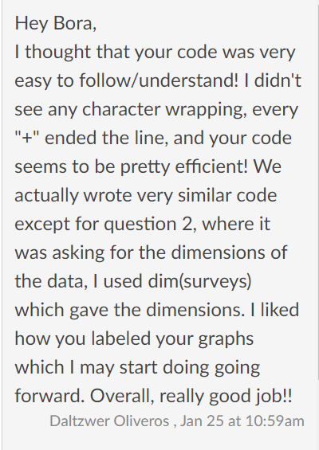

Similar to what I wrote in the “Extending My Thinking” section of our reflection, often times, I find myself hesitant to provide more useful feedback due to my fear of giving the wrong answer. Despite my limited knowledge and skill set, however, I believe I have done well in this aspect of our class. I complete our weekly Peer Reviews on time while trying to be as detailed as I can about the things my peer should keep doing or improve upon. In our groups, I have acted on my role as best as I can without going into someone’s role while being patient and respectful. I try to clarify any ambiguity my group members may have when I can and help debug their code for our lab assignments. Towards the end of our quarter, I started to really feel like I began to contribute to our group assignments especially when it came to week nine.